# Assignment 2

Jaime Wu

06/09/2020

# NYC Taxi - Prediction of taxi tips

```r
library(tidyverse)
library(ggplot2)
library(lubridate)
library(leaflet)
library(leaps)
library(rgdal)
library(sp)
```

## Background

In the USA, a significant part of the wages of many service workers come from tips, nominally voluntary payments by the customer in addition to the listed price. For taxis in New York, tourist advice suggests a tip of 15-20%. Data from two weeks of taxi trips in New York City, including information on the time of day, day of the week, trip distance, price, number of passengers, locations of pickup and dropoff is given. The data from week 2 of January 2016 will be explored, cleaned, and used to construct a model for predicting the amount of tips on the data from week 4 of January 2016. The mean square prediction error will be evaluated to determine the effectiveness and accuracy of the model.

## Data Exploration and Cleaning

```r
# Load the taxi data for week 2, summarise each variable and inspect for abnormalities
week2 <- read_csv("./data/week2.csv")
week2 %>% summary()
```

```
##     VendorID     tpep_pickup_datetime          tpep_dropoff_datetime
##  Min.   :1.000   Min.   :2016-01-08 00:00:00   Min.   :2016-01-08 00:01:23
##  1st Qu.:1.000   1st Qu.:2016-01-09 18:02:05   1st Qu.:2016-01-09 18:16:14
##  Median :2.000   Median :2016-01-11 15:19:10   Median :2016-01-11 15:33:52
##  Mean   :1.532   Mean   :2016-01-11 14:11:04   Mean   :2016-01-11 14:25:25
##  3rd Qu.:2.000   3rd Qu.:2016-01-13 11:35:15   3rd Qu.:2016-01-13 11:50:25
##  Max.   :2.000   Max.   :2016-01-14 23:59:59   Max.   :2016-01-15 23:39:18
##  passenger_count trip_distance     pickup_longitude  pickup_latitude
##  Min.   :0.000   Min.   :  0.000   Min.   :-121.93   Min.   : 0.00
##  1st Qu.:1.000   1st Qu.:  1.000   1st Qu.: -73.99   1st Qu.:40.74
##  Median :1.000   Median :  1.630   Median : -73.98   Median :40.75
##  Mean   :1.659   Mean   :  2.809   Mean   : -72.84   Mean   :40.13
##  3rd Qu.:2.000   3rd Qu.:  3.000   3rd Qu.: -73.97   3rd Qu.:40.77
##  Max.   :9.000   Max.   :502.200   Max.   :   0.00   Max.   :46.31
##    RatecodeID     store_and_fwd_flag dropoff_longitude dropoff_latitude
##  Min.   : 1.000   Length:2651287     Min.   :-121.93   Min.   : 0.00
##  1st Qu.: 1.000   Class :character   1st Qu.: -73.99   1st Qu.:40.74
##  Median : 1.000   Mode  :character   Median : -73.98   Median :40.75
##  Mean   : 1.036                      Mean   : -72.91   Mean   :40.17
##  3rd Qu.: 1.000                      3rd Qu.: -73.96   3rd Qu.:40.77
##  Max.   :99.000                      Max.   :   0.00   Max.   :52.75
##   payment_type    fare_amount          extra             mta_tax
##  Min.   :1.000   Min.   :-957.60   Min.   :-35.6400   Min.   :-0.5000
##  1st Qu.:1.000   1st Qu.:   6.50   1st Qu.:  0.0000   1st Qu.: 0.5000
##  Median :1.000   Median :   9.00   Median :  0.0000   Median : 0.5000
##  Mean   :1.337   Mean   :  12.06   Mean   :  0.3235   Mean   : 0.4978
##  3rd Qu.:2.000   3rd Qu.:  13.50   3rd Qu.:  0.5000   3rd Qu.: 0.5000
##  Max.   :4.000   Max.   :3039.00   Max.   :  4.1000   Max.   :36.4400
##    tip_amount        tolls_amount      improvement_surcharge  total_amount
##  Min.   :-220.800   Min.   :-12.5000   Min.   :-0.3000       Min.   :-958.40
##  1st Qu.:   0.000   1st Qu.:  0.0000   1st Qu.: 0.3000       1st Qu.:   8.30
##  Median :   1.320   Median :  0.0000   Median : 0.3000       Median :  11.30
##  Mean   :   1.728   Mean   :  0.2746   Mean   : 0.2998       Mean   :  15.18
##  3rd Qu.:   2.260   3rd Qu.:  0.0000   3rd Qu.: 0.3000       3rd Qu.:  16.56
##  Max.   : 900.000   Max.   :811.0000   Max.   : 0.3000       Max.   :3045.34
```

```r
dim(week2)
```

```
## [1] 2651287      19
```

```r
# Explore the categorical variables
week2 %>% count(VendorID)
```

```
## # A tibble: 2 x 2
##   VendorID       n
##      <dbl>   <int>
## 1        1 1241239
## 2        2 1410048
```

```r
week2 %>% count(payment_type)
```

```
## # A tibble: 4 x 2
##   payment_type       n
##          <dbl>   <int>
## 1            1 1773438
## 2            2  865853
## 3            3    8932
## 4            4    3064
```

```r
week2 %>% count(RatecodeID)
```

```
## # A tibble: 7 x 2
##   RatecodeID       n
##        <dbl>   <int>
## 1          1 2589456
## 2          2   49557
## 3          3    3587
## 4          4    1022
## 5          5    7582
## 6          6      24
## 7         99      59
```

```r
week2 %>% count(extra)
```

```
## # A tibble: 16 x 2
##     extra       n
##     <dbl>   <int>
##  1 -35.6        1
##  2  -1        135
##  3  -0.5      312
##  4   0    1373473
##  5   0.02       4
##  6   0.04       1
##  7   0.3        1
##  8   0.45       1
##  9   0.5   838520
## 10   1     438816
## 11   1.3        1
## 12   1.45       1
## 13   1.5       14
## 14   2          3
## 15   2.5        3
## 16   4.1        1
```

According to the data dictionary for yellow taxis, the tip amount is only recorded for credit card transactions. Cash tips are not included, so the cash transactions should be removed. Although many data points will be removed (~870,000), cash transactions will always have zero tips, which is not beneficial for building a model for predicting tips.

The 59 observations with a rate code id of 99 should be removed as it has not been defined in the data dictionary, indicating erroneous data.

The MTA tax and improvement surcharges are flat fees attached to every NYC taxi ride, so they will provide no additional benefit to the model and should be removed. Likewise, the variable Store and forward flag also provide no additional benefit to the model as it relates to whether or not the taxi had a connection to the server. Removing the flag should not affect the predictions of the taxi tips. Finally, the total amount should also be removed as it already includes the tip amount, and so cannot be used to predict the tip amount.

```r
# Convert some variables into factors and create a new column for trip duration
dim(week2)
```

```
## [1] 2651287      19
```

```r
week2 <- week2 %>%
  mutate(
    VendorID = factor(VendorID),
    trip_duration = as.numeric(difftime(tpep_dropoff_datetime, tpep_pickup_datetime, unit = "mins")),
    RatecodeID_label =  fct_recode(factor(RatecodeID), # Convert the rate code id into its proper label as defined in the data dictionary
                                    "Standard Rate"="1",
                                    "JFK" = "2",
                                    "Newark" = "3",
                                    "NassauWestchester" = "4",
                                    "Negotiated Fare" = "5",
                                    "Group ride" = "6"),
    payment_type_label = fct_recode(factor(payment_type), # Convert the payment type id into its proper label as defined in the data dictionary
                                    "Credit Card"="1",
                                    "Cash" = "2",
                                    "No Charge" = "3",
                                    "Dispute" = "4"),
    ) %>%
  select(-c(mta_tax, improvement_surcharge, store_and_fwd_flag, RatecodeID, payment_type, total_amount)) %>% # Remove unwanted variables
  filter(
    RatecodeID_label != 99, # Filter out the observations with rate code id equal to 99
    extra == 0 | extra == 0.5 |extra == 1.0, # Filter out the observations that are not zero, rush hour, and overnight charges.
    payment_type_label != "Cash" # Exclude cash transactions as they don't include the tip amount
  ) %>%
  mutate(
    extra = factor(extra) # Convert into a factor
  )
dim(week2)
```

```
## [1] 1784957      16
```

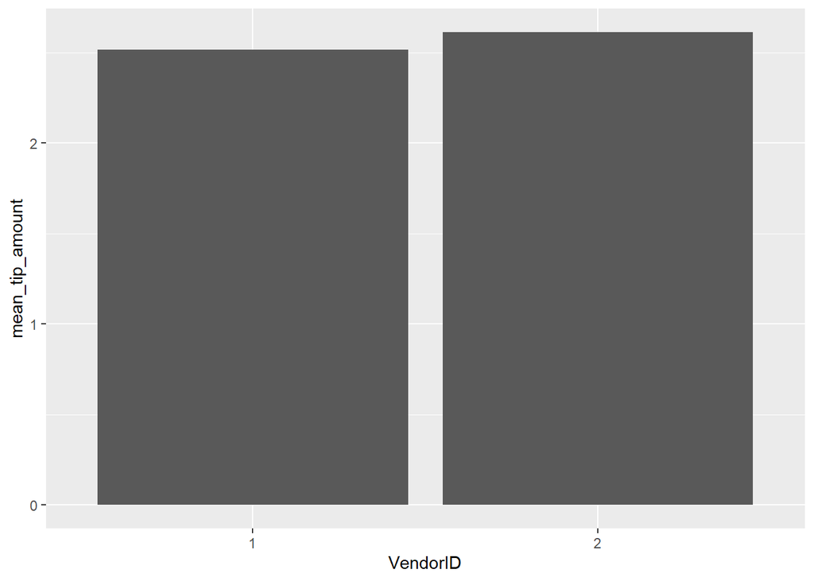

```r
# Explore the categorical variables graphically
week2 %>%
  group_by(VendorID) %>%
  summarise(mean_tip_amount = mean(tip_amount)) %>%
  ggplot(aes(x = VendorID, y = mean_tip_amount)) + geom_histogram(stat = "identity")
```

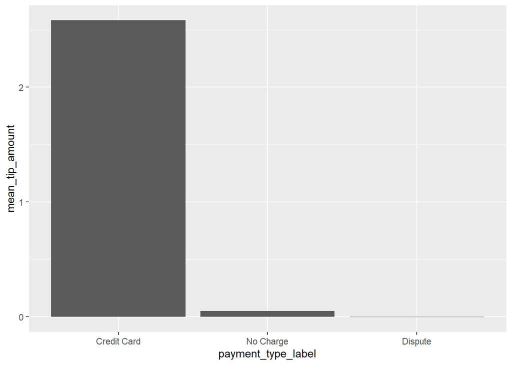

```r
week2 %>%
  group_by(payment_type_label) %>%
  summarise(mean_tip_amount = mean(tip_amount)) %>%
  ggplot(aes(x = payment_type_label, y = mean_tip_amount)) + geom_histogram(stat = "identity")
```

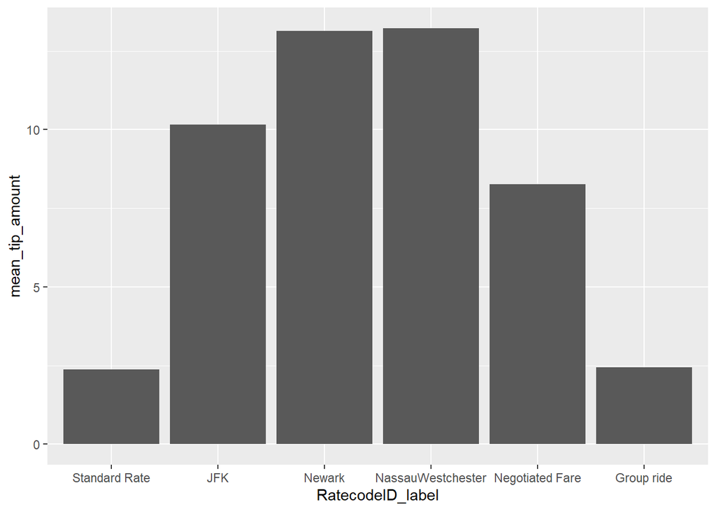

```r
week2 %>%
  group_by(RatecodeID_label) %>%
  summarise(mean_tip_amount = mean(tip_amount)) %>%
  ggplot(aes(x = RatecodeID_label, y = mean_tip_amount)) + geom_histogram(stat = "identity")
```

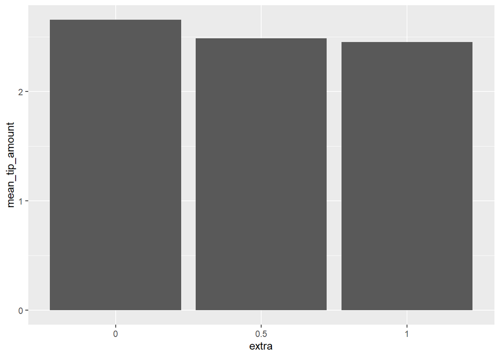

```r
week2 %>%
  group_by(extra) %>%
  summarise(mean_tip_amount = mean(tip_amount)) %>%
  ggplot(aes(x = extra, y = mean_tip_amount)) + geom_histogram(stat = "identity")
```

The average tip was similar for both taxi vendors.

The average tip was highest for credit card as expected compared to the other types.

The average tip is different for each rate code id type. Newark and Westchester has the highest average tip which is expected as they are one of the richest counties/regions of the US. JFK is likely referring to the airport which is also expected to have a higher tip than the other types. The negotiated fare type being higher than the standard rate also is logical as passengers would be more happy and likely to tip the taxi driver.

The average tip decreases as extra charges are incurred which is also logically sound; however, the difference is not extremely significant.

There are likely interactions between these categorical variables, with the most probably variable being the rate code id label. The other variables do not appear to have as much of an effect on tip amount.

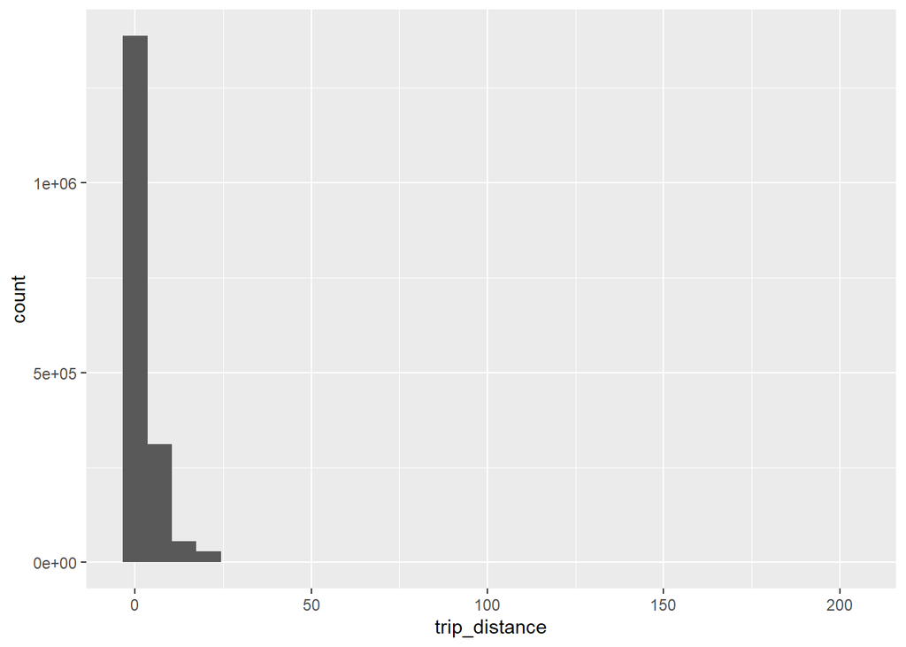

```r
# Explore numerical variables first and clean if necessary
week2 %>% ggplot(aes(x = trip_distance)) + geom_histogram()
```

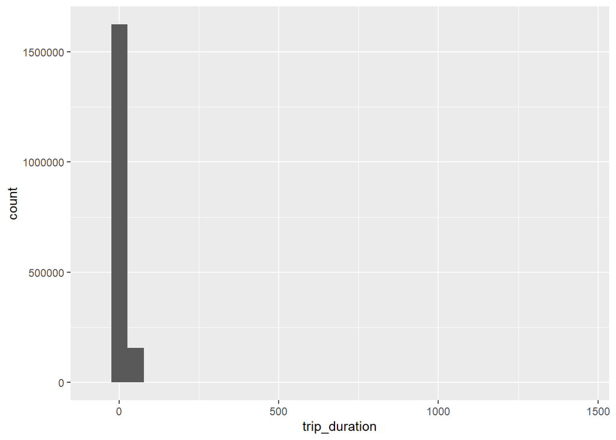

```r
week2 %>% ggplot(aes(x = trip_duration)) + geom_histogram()
```

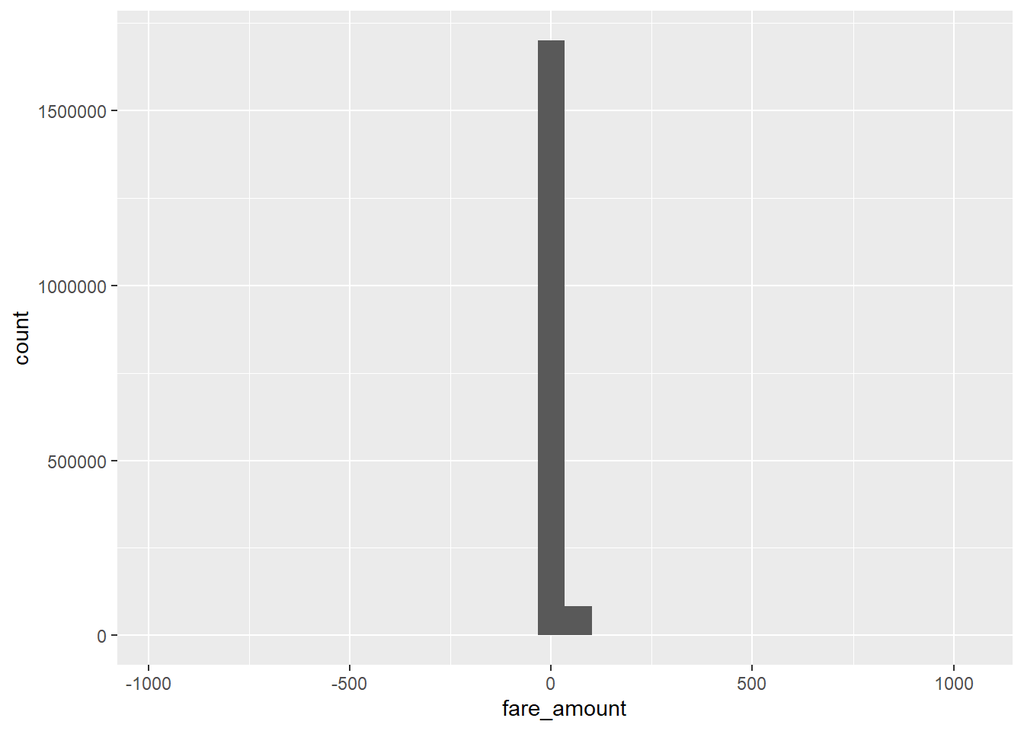

```r
week2 %>% ggplot(aes(x = fare_amount)) + geom_histogram()
```

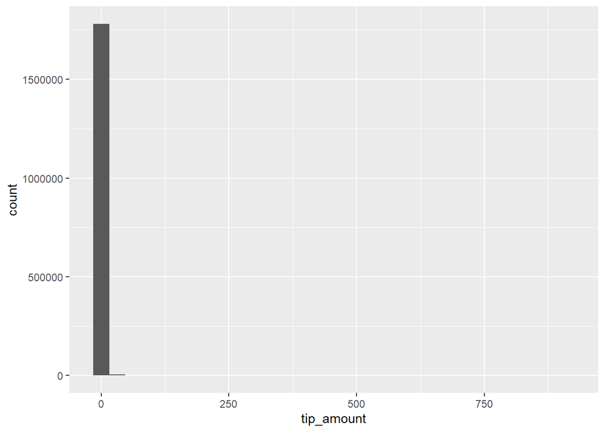

```r
week2 %>% ggplot(aes(x = tip_amount)) + geom_histogram()
```

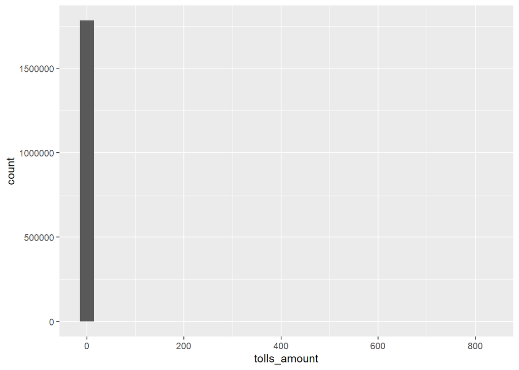

```r
week2 %>% ggplot(aes(x = tolls_amount)) + geom_histogram()
```

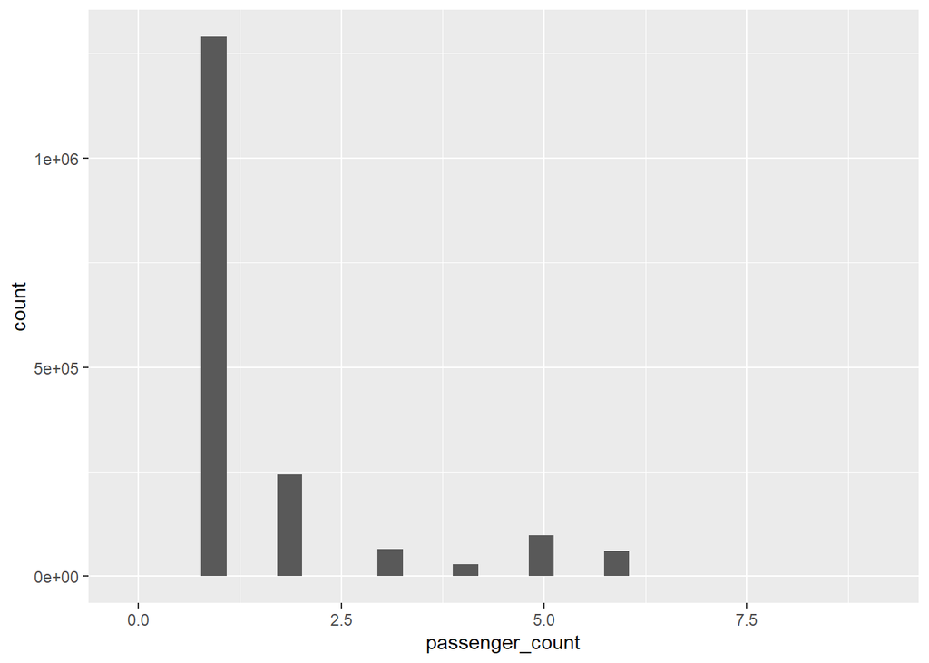

```r
week2 %>% ggplot(aes(x = passenger_count)) + geom_histogram()
```

```r
week2 %>% count(trip_distance > 0) # Unlikely for trip distance to be 0 or less
```

```
## # A tibble: 2 x 2
##   `trip_distance > 0`       n
##   <lgl>                 <int>
## 1 FALSE                  7782
## 2 TRUE                1777175
```

```r
week2 %>% count(trip_duration > 0) # Unlikely for trip duration to be 0 or less
```

```
## # A tibble: 2 x 2
##   `trip_duration > 0`       n
##   <lgl>                 <int>
## 1 FALSE                    79
## 2 TRUE                1784878
```

```r
week2 %>% count(fare_amount > 0) # Unlikely for fare to be 0 or less
```

```
## # A tibble: 2 x 2
##   `fare_amount > 0`       n
##   <lgl>               <int>
## 1 FALSE                 780
## 2 TRUE              1784177
```

```r
week2 %>% count(tip_amount >= 0) # Unlikely for negative tips
```

```
## # A tibble: 2 x 2
##   `tip_amount >= 0`       n
##   <lgl>               <int>
## 1 FALSE                  17
## 2 TRUE              1784940
```

```r
week2 %>% count(tolls_amount >= 0) # Unlikely for negative tolls
```

```
## # A tibble: 2 x 2
##   `tolls_amount >= 0`       n
##   <lgl>                 <int>
## 1 FALSE                     3
## 2 TRUE                1784954
```

The summary statistics of the numerical variables, trip distance, fare amount, tip amount, and toll amount show that they all have maximum values that are beyond the 3rd quartile by a significant amount. Additionally, the plots of the numerical variables show that there are extreme outliers in the data that should be removed.

It is also unlikely that these numerical variables are negative, and there are not many observations with negative values, so it is probably that those observations are errors and should be removed.

```r
# Filter numerical variables within a holistic range
dim(week2)
```

```
## [1] 1784957      16
```

```r
week2 <- week2 %>%
  filter(
    trip_distance > 0,
    trip_distance <= 50,
    trip_duration > 0,
    trip_duration <= 120,
    fare_amount > 0,
    fare_amount <= 100,
    tip_amount >= 0,
    tip_amount <= 50,
    tolls_amount >= 0,
    tolls_amount <= 50
    )
dim(week2)
```

```
## [1] 1773463      16
```

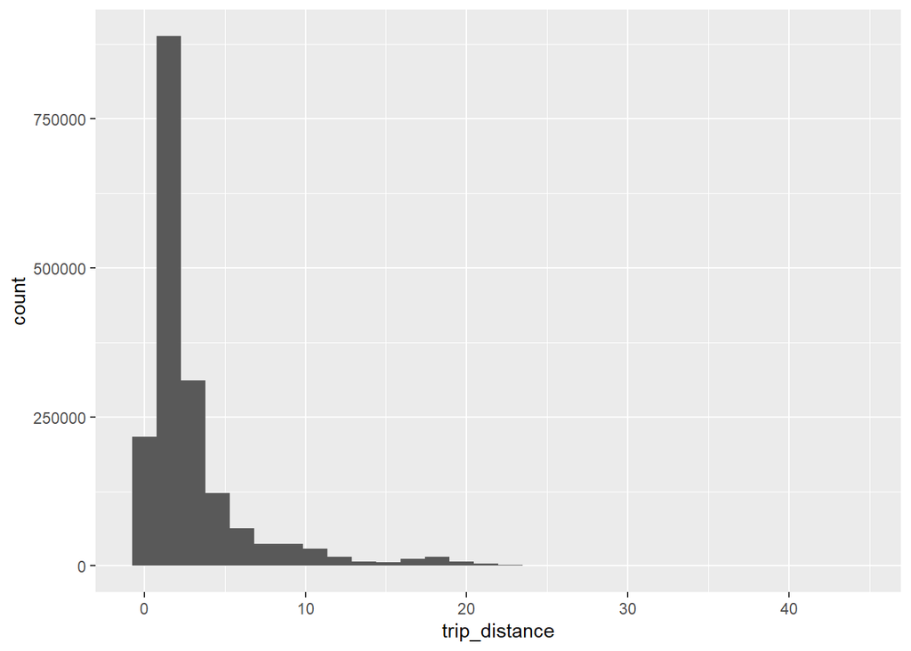

```r
# Re-examine numerical variables and look for obvious outliers
week2 %>% ggplot(aes(x = trip_distance)) + geom_histogram()
```

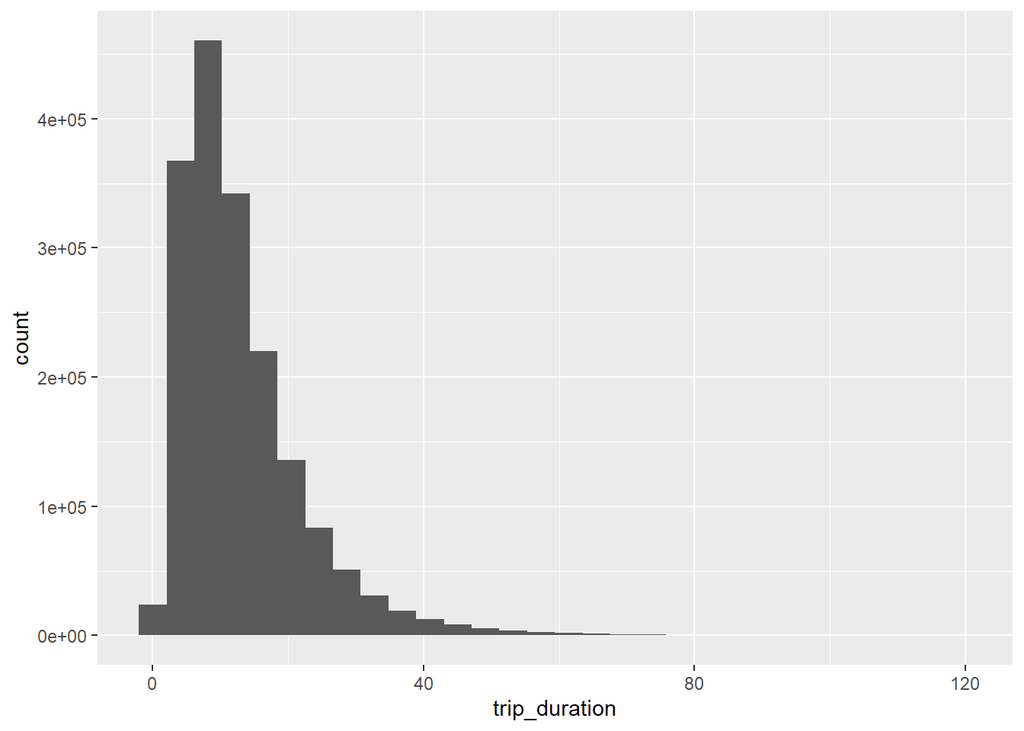

```r
week2 %>% ggplot(aes(x = trip_duration)) + geom_histogram()
```

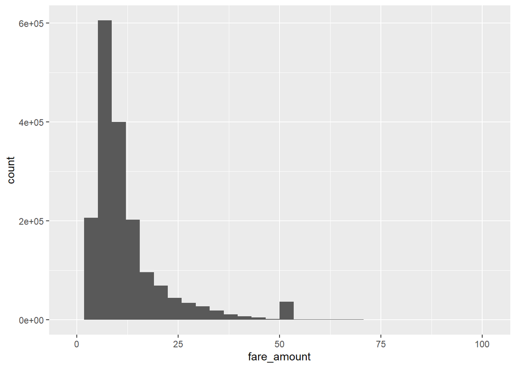

```r
week2 %>% ggplot(aes(x = fare_amount)) + geom_histogram()
```

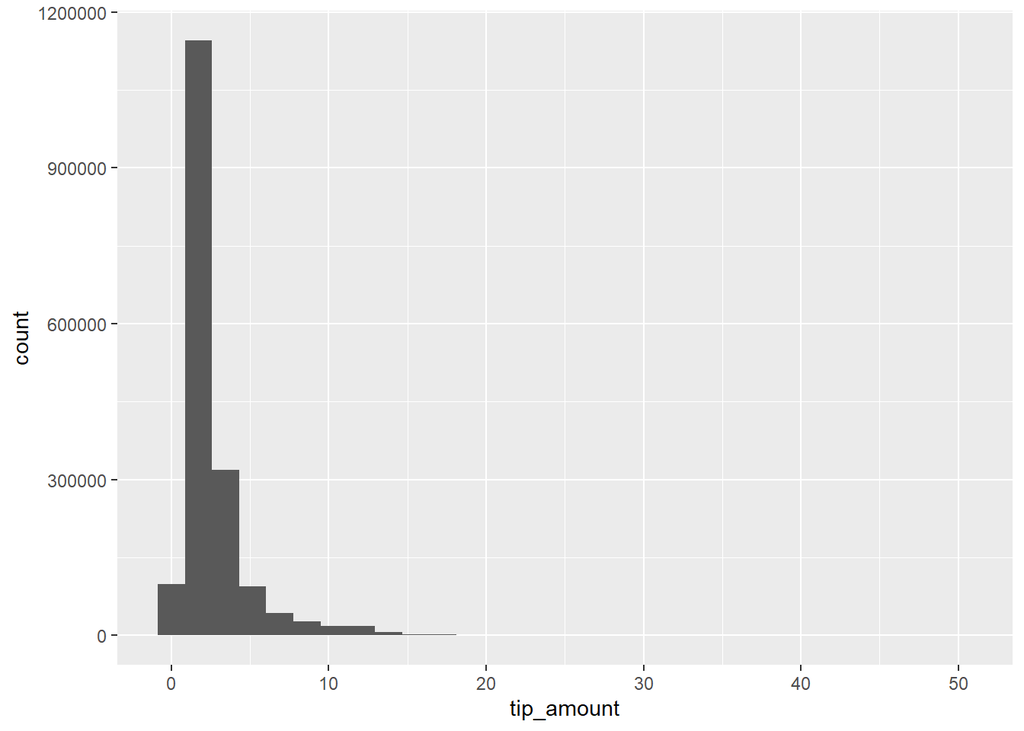

```r
week2 %>% ggplot(aes(x = tip_amount)) + geom_histogram()
```

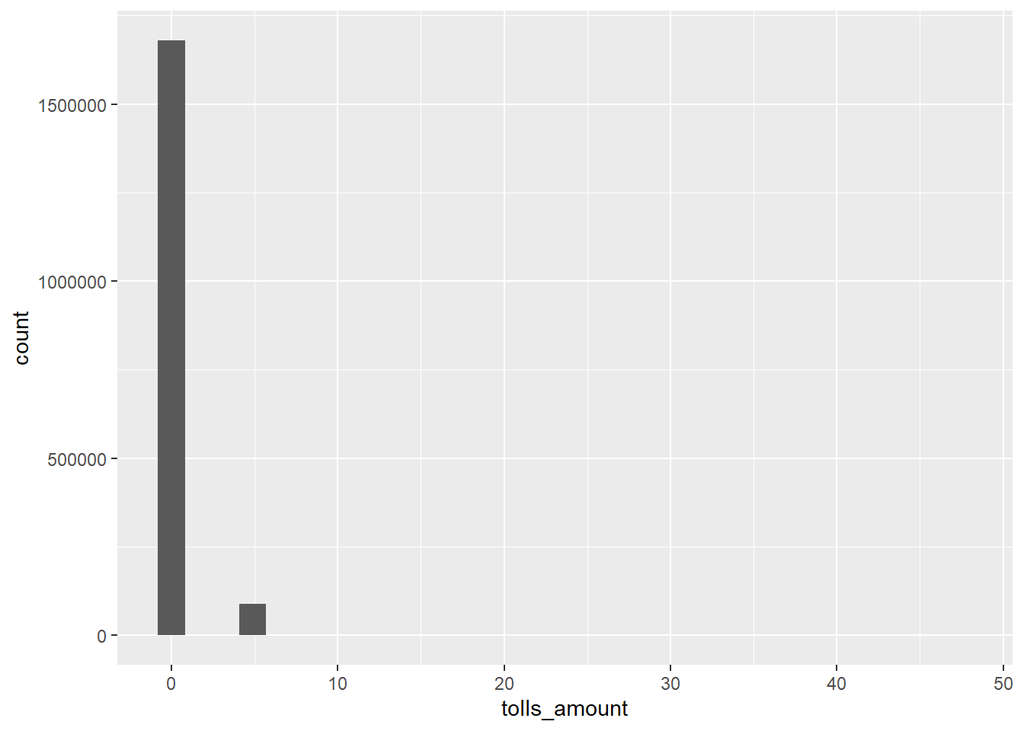

```r
week2 %>% ggplot(aes(x = tolls_amount)) + geom_histogram()
```

The numerical variables, trip distance, fare amount, tip amount, and tolls amount was holistically filtered with an upper range, removing approximately 10,000 observations which is reasonable as this is less than 1% of the total data. The number of passengers does not appear to have any outliers in the data, so no observations were removed.

The plots appear sensible post-filtration, but the spike in the number of fare amounts around $50.00 is questionable, nevertheless is still a fair distribution. The histogram of the amount of the tolls seems categorical, with a majority of trips having no tolls, so the amount of the tolls can be factored into two levels: toll or no toll. The numerical variables are all right-skewed which means that the median will give a better measure of centrality.

```r
# Convert tolls amount into a factor: true if there is a toll for the trip, and false if there is no toll for the trip.
week2 <- week2 %>%
  mutate(
    toll = factor(tolls_amount != 0)
  ) %>%
  select(
    -tolls_amount
  )
```

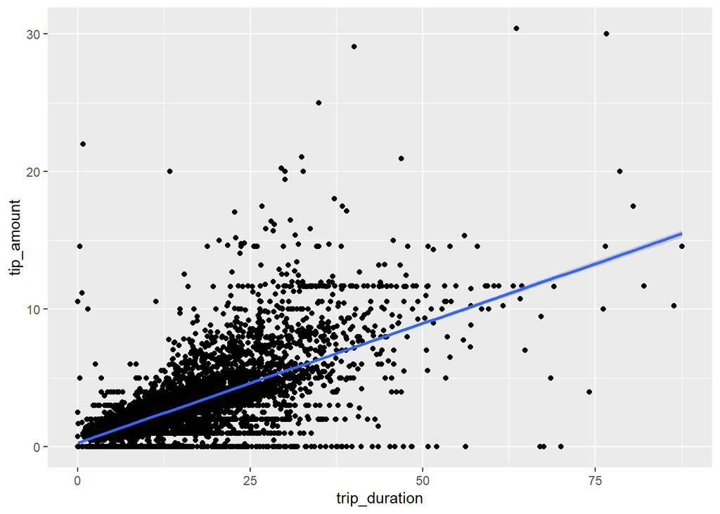

```r
# Exploration of the numerical variables with tip amount
week2 %>% sample_n(1e4) %>% ggplot(aes(x = trip_duration, y = tip_amount)) + geom_point() + geom_smooth(method = "lm")
```

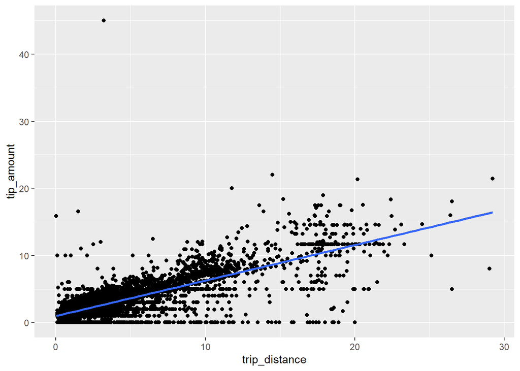

```r
week2 %>% sample_n(1e4) %>% ggplot(aes(x = trip_distance, y = tip_amount)) + geom_point() + geom_smooth(method = "lm")
```

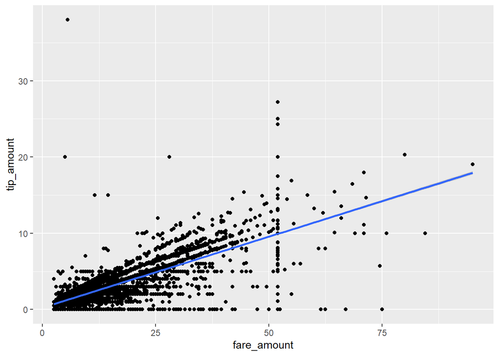

```r
week2 %>% sample_n(1e4) %>% ggplot(aes(x = fare_amount, y = tip_amount)) + geom_point() + geom_smooth(method = "lm")
```

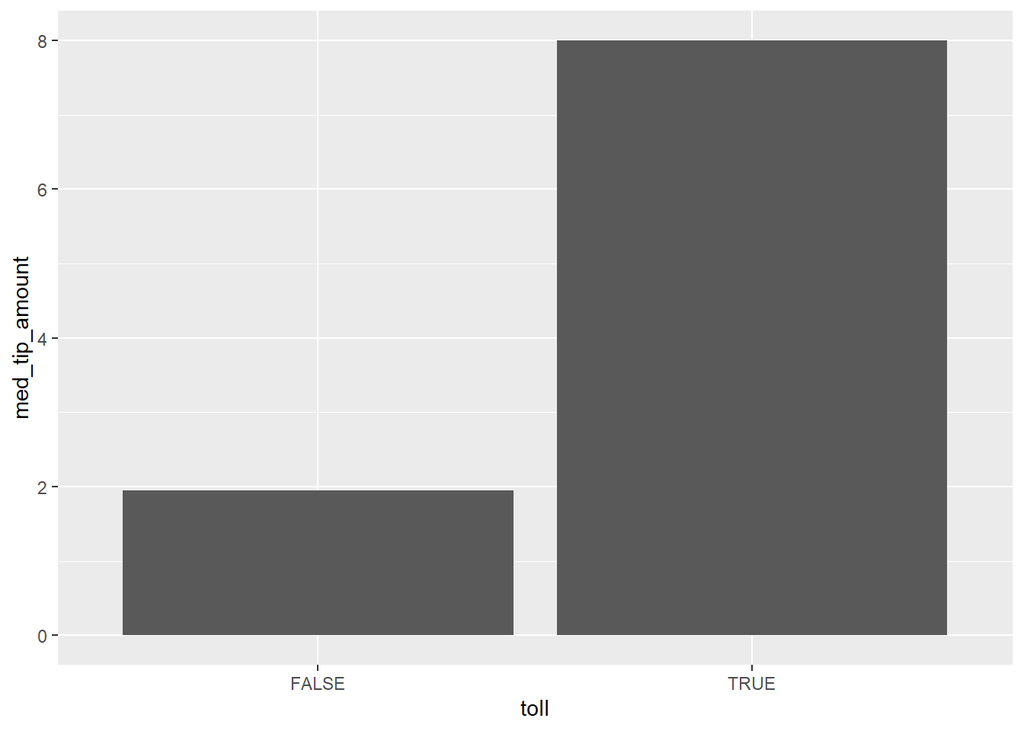

```r
week2 %>% group_by(toll) %>% summarise(med_tip_amount = median(tip_amount)) %>% ggplot(aes(x = toll, y = med_tip_amount)) + geom_bar(stat = "identity")
```

The plots are as expected, and there is an obvious positive linear relationship between trip distance and tip amount, trip duration and tip amount, and fare amount and tip amount. Multicollinearity is likely to be present in the data as the trip distance, trip duration, and fare amount are all positively correlated to the tip amount. The interesting result from these plots is a trip with toll results in a larger median tip.

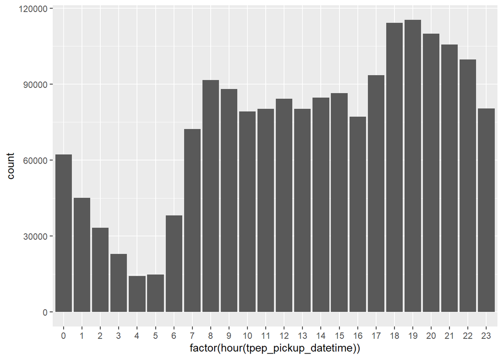

```r
# Quick plot of the hourly pattern
week2 %>%
  ggplot(aes(x = factor(hour(tpep_pickup_datetime)))) + geom_bar()
```

The pickup and dropoff time data is in the NYC timezone as the hourly pickup of passengers look reasonably realistic and follows a day-night cycle. The pickup time of day will be factored into four categories to reflect the day-night cycle, with morning (6am - 12pm), afternoon (12pm - 6pm), evening (6pm - 12am) and night (12am - 6am). Similarly, the dropoff time of day will also be converted to a factor in the same way.

```r
# Converting pickup time into time of day factor
# Retrieved from https://stackoverflow.com/questions/50304159/label-day-timing-into-morning-afternoon-and-evening-in-r
week2 <- week2 %>%
  mutate(
    pickup_time_of_day = cut(x = hour(tpep_pickup_datetime), breaks = hour(hm("00:00", "6:00", "12:00", "18:00", "23:59")), labels = c("Night", "Morning", "Afternoon", "Evening"), include.lowest = TRUE),
    dropoff_time_of_day = cut(x = hour(tpep_dropoff_datetime), breaks = hour(hm("00:00", "6:00", "12:00", "18:00", "23:59")), labels = c("Night", "Morning", "Afternoon", "Evening"), include.lowest = TRUE)
  )
```

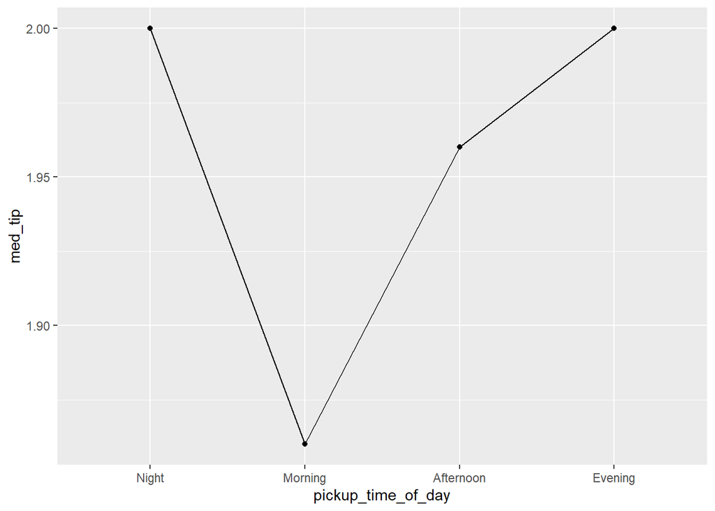

```r
# Visualise variation of the tip amounts over the day
week2 %>%
  group_by(pickup_time_of_day) %>%
  summarise(med_tip = median(tip_amount)) %>%
  ggplot(aes(x = pickup_time_of_day, y = med_tip, group = 1)) + geom_point() + geom_line()
```

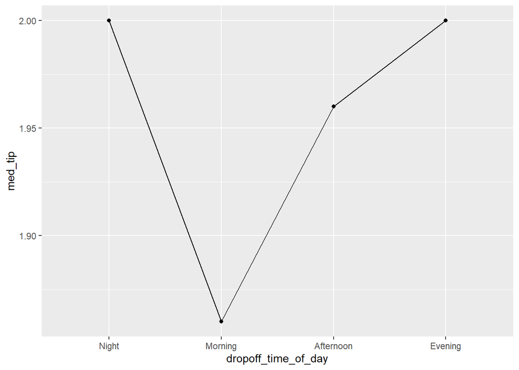

```r
week2 %>%
  group_by(dropoff_time_of_day) %>%
  summarise(med_tip = median(tip_amount)) %>%
  ggplot(aes(x = dropoff_time_of_day, y = med_tip, group = 1)) + geom_point() + geom_line()
```

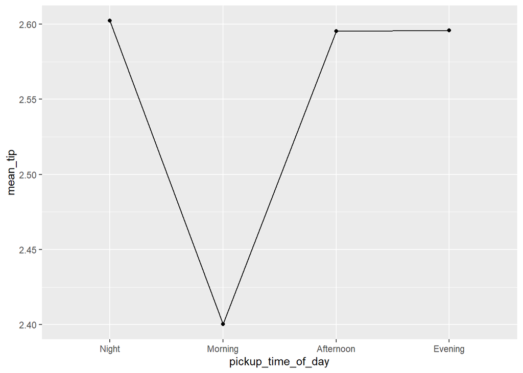

```r
week2 %>%
  group_by(pickup_time_of_day) %>%
  summarise(mean_tip = mean(tip_amount)) %>%
  ggplot(aes(x = pickup_time_of_day, y = mean_tip, group = 1)) + geom_point() + geom_line()
```

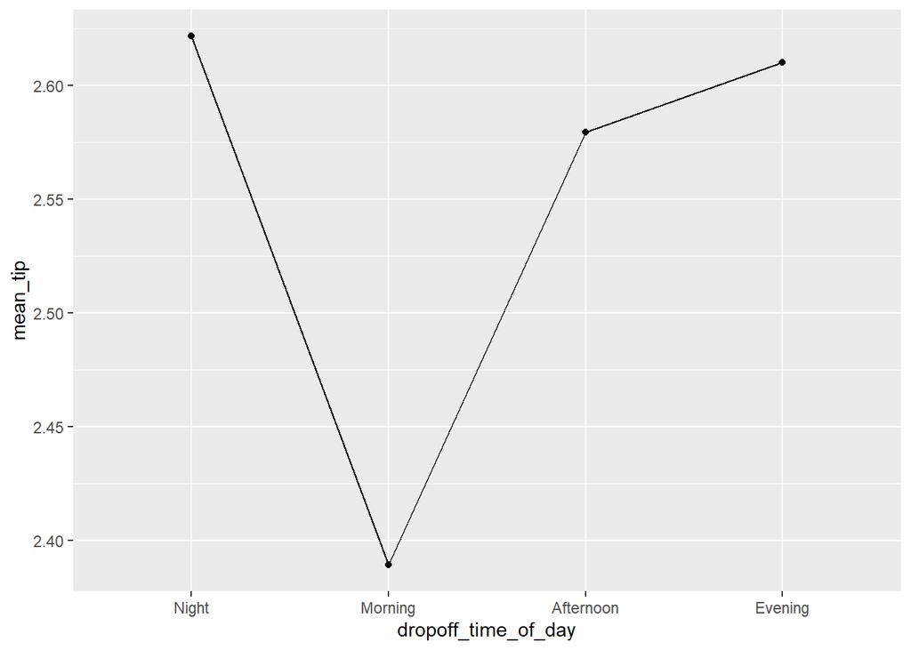

```r
week2 %>%
  group_by(dropoff_time_of_day) %>%
  summarise(mean_tip = mean(tip_amount)) %>%
  ggplot(aes(x = dropoff_time_of_day, y = mean_tip, group = 1)) + geom_point() + geom_line()
```

There are variations in the tip amount over the day. The evening and night tend to high a higher average and median tip than in the morning and this increases in the afternoon. Perhaps, passengers are more likely to tip drivers that working later in the day and appreciate their late shifts.

```r
# Create day of the week column
week2 <- week2 %>%
  mutate(
    dow = factor(wday(tpep_pickup_datetime, label = TRUE, abbr = TRUE, week_start = 1)),
  )

# Remove date time variables as they have been converted into factors
week2 <- week2 %>%
  select(-c(tpep_pickup_datetime, tpep_dropoff_datetime))
```

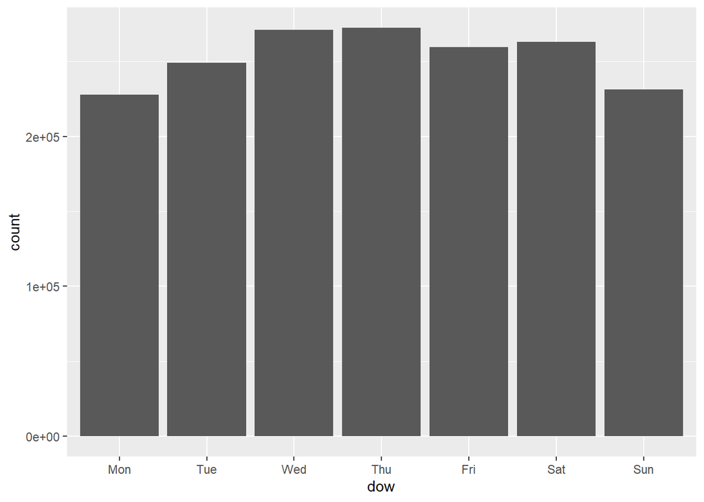

```r
# Visualise variations over the week
week2 %>% ggplot(aes(x = dow)) + geom_bar()
```

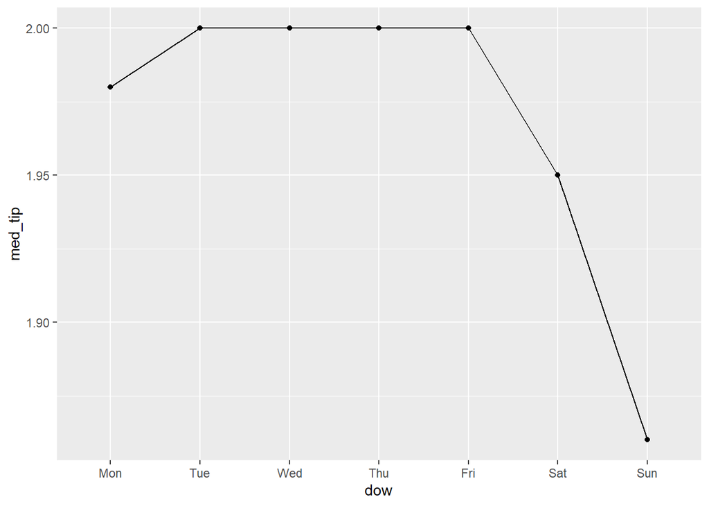

```r
# Visualise variations of the tip amounts over the week
week2 %>%
  group_by(dow) %>%
  summarise(med_tip = median(tip_amount)) %>%
  ggplot(aes(x = dow, y = med_tip, group = 1)) + geom_point() + geom_line()
```

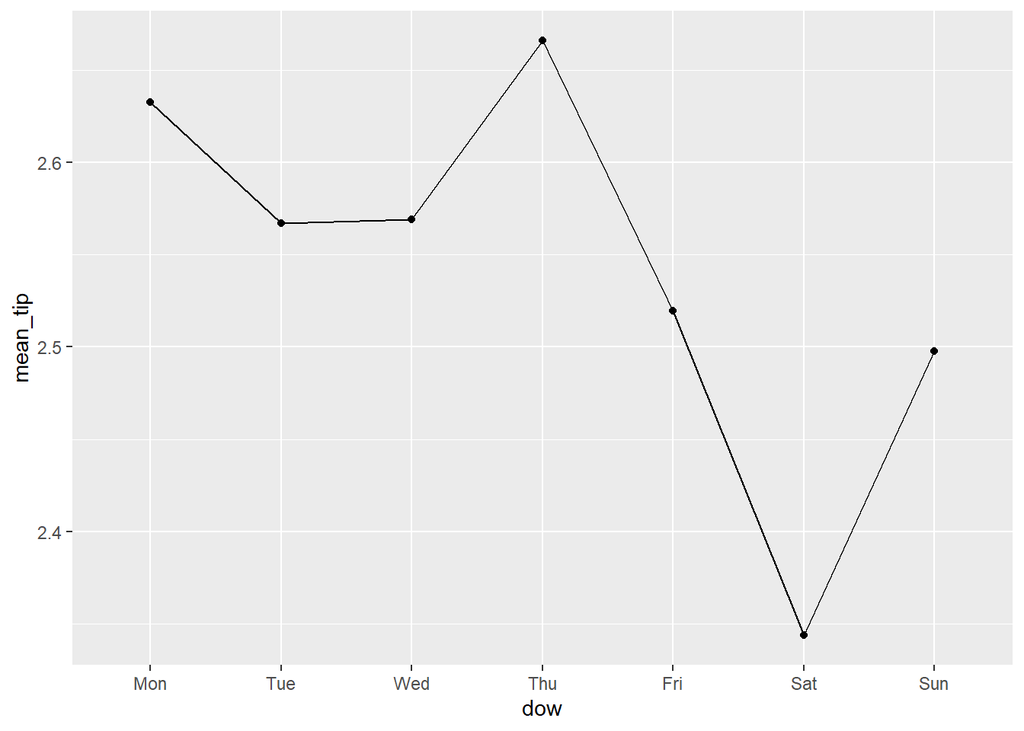

```r
week2 %>%
  group_by(dow) %>%
  summarise(mean_tip = mean(tip_amount)) %>%
  ggplot(aes(x = dow, y = mean_tip, group = 1)) + geom_point() + geom_line()
```

The number of trips over each day of the week seems reasonable - there does not appear to be any patterns or variations. However, the tip amount varies over the course of the week, with the tip amount increasing at the start of the week to a maximum during the middle of the week and then decreases over the weekend. The lower tip amount over the weekend is somewhat surprising as the number of trips is similar throughout the week, and it is normally expected that people tip more when they go out more during the weekend.

```r
# Explore location data
week2 %>% sample_n(1e4) %>% leaflet() %>% addTiles() %>% addCircleMarkers(~pickup_longitude, ~pickup_latitude, radius = 2) %>% addCircleMarkers(~dropoff_longitude, ~dropoff_latitude, radius = 2, color = "Red")
```

[interactive chart not shown]

The NYC taxi data should only have data that is located within New York. The locations recorded outside New York are likely due to an error in the data collection process, i.e. malfunctioning GPS, in which case those observations should be removed.

```r
# Ensure all data points are in NYC
dim(week2)
```

```
## [1] 1773463      17
```

```r
week2 <- week2 %>%
  filter(
    pickup_latitude > 40.495992,
    pickup_latitude < 40.915568,
    pickup_longitude > -74.257159,
    pickup_longitude < -73.699215,
    dropoff_latitude > 40.495992,
    dropoff_latitude < 40.915568,
    dropoff_longitude > -74.257159,
    dropoff_longitude < -73.699215,
    )
dim(week2) # Approximately 30,000 observations are removed which is not too significant
```

```
## [1] 1746764      17
```

```r
# Read in the borough boundaries of NYC from shape files
nyboroughs <- readOGR("./data/Borough Boundaries")
# Define pickup and dropoff locations as spatial points
pickup_points <- week2 %>% select(longitude = pickup_longitude, latitude = pickup_latitude) %>% SpatialPoints(proj4string = CRS(proj4string(nyboroughs)))
dropoff_points <- week2 %>% select(longitude = dropoff_longitude, latitude = dropoff_latitude) %>% SpatialPoints(proj4string = CRS(proj4string(nyboroughs)))

# Categorise pickup and dropoff locations into boroughs via the intersection between the spatial points and the spatial polygons
pickup_borough = over(pickup_points, nyboroughs)
dropoff_borough = over(dropoff_points, nyboroughs)

# Replace the pickup and dropoff lat/long with the corresponding pickup and dropoff borough
week2 <- week2 %>%
  mutate(
    pickup_borough = pickup_borough$boro_name,
    dropoff_borough = dropoff_borough$boro_name
  ) %>%
  select(-c(pickup_longitude, pickup_latitude, dropoff_longitude, dropoff_latitude))

# Remove any missing data
dim(week2)
```

```
## [1] 1746764      15
```

```r
week2 <- week2[!rowSums(is.na(week2)) > 0,]
dim(week2) # About 5000 observations have missing data which is not a lot so we can remove them
```

```
## [1] 1741791      15
```

After cleaning the week 2 data, the number of observations reduced from 2651287 to 1741791, which is about 900,000. Although this is quite a fair amount of data, approximately 870,000 of those data points come from cash transactions. As explained previously, tips for cash transactions are not recorded according to the data dictionary and would not help to build a model. Overall, only 30,000 observations were removed that were not cash transactions, and this is an acceptable amount.

```r
# Save cleaned data
write_csv(week2, "./data/week2clean.csv")
```

```r
# Clear memory so R can knit file
rm(list=ls())
gc()
```

```
##            used  (Mb) gc trigger   (Mb)  max used   (Mb)
## Ncells  2452224 131.0    7884111  421.1  15398652  822.4
## Vcells 11223458  85.7  140908548 1075.1 192270352 1467.0
```

```r
# Week 4 taxi data
week4 <- read_csv("./data/week4.csv")
week4 %>% summary()
```

```
##     VendorID     tpep_pickup_datetime          tpep_dropoff_datetime
##  Min.   :1.000   Min.   :2016-01-22 00:00:00   Min.   :2016-01-22 00:00:00
##  1st Qu.:1.000   1st Qu.:2016-01-24 09:46:29   1st Qu.:2016-01-24 09:58:29
##  Median :2.000   Median :2016-01-26 08:49:09   Median :2016-01-26 09:09:57
##  Mean   :1.541   Mean   :2016-01-25 21:47:14   Mean   :2016-01-25 22:04:26
##  3rd Qu.:2.000   3rd Qu.:2016-01-27 18:40:39   3rd Qu.:2016-01-27 18:57:26
##  Max.   :2.000   Max.   :2016-01-28 23:59:59   Max.   :2016-02-03 08:28:27
##  passenger_count trip_distance     pickup_longitude  pickup_latitude
##  Min.   :0.00    Min.   :      0   Min.   :-121.93   Min.   : 0.00
##  1st Qu.:1.00    1st Qu.:      1   1st Qu.: -73.99   1st Qu.:40.74
##  Median :1.00    Median :      2   Median : -73.98   Median :40.75
##  Mean   :1.65    Mean   :      6   Mean   : -72.90   Mean   :40.16
##  3rd Qu.:2.00    3rd Qu.:      3   3rd Qu.: -73.97   3rd Qu.:40.77
##  Max.   :9.00    Max.   :4667469   Max.   :   0.00   Max.   :48.26
##    RatecodeID     store_and_fwd_flag dropoff_longitude dropoff_latitude
##  Min.   : 1.000   Length:2010309     Min.   :-121.93   Min.   : 0.00
##  1st Qu.: 1.000   Class :character   1st Qu.: -73.99   1st Qu.:40.74
##  Median : 1.000   Mode  :character   Median : -73.98   Median :40.75
##  Mean   : 1.043                      Mean   : -72.97   Mean   :40.20
##  3rd Qu.: 1.000                      3rd Qu.: -73.96   3rd Qu.:40.77
##  Max.   :99.000                      Max.   :   0.00   Max.   :45.14
##   payment_type    fare_amount          extra            mta_tax
##  Min.   :1.000   Min.   :-434.00   Min.   :-4.5000   Min.   :-0.5000
##  1st Qu.:1.000   1st Qu.:   6.50   1st Qu.: 0.0000   1st Qu.: 0.5000
##  Median :1.000   Median :   9.50   Median : 0.5000   Median : 0.5000
##  Mean   :1.326   Mean   :  13.32   Mean   : 0.3554   Mean   : 0.4975
##  3rd Qu.:2.000   3rd Qu.:  15.00   3rd Qu.: 0.5000   3rd Qu.: 0.5000
##  Max.   :4.000   Max.   :5000.00   Max.   : 5.0000   Max.   : 3.0000
##    tip_amount       tolls_amount      improvement_surcharge  total_amount
##  Min.   :-70.000   Min.   :-10.5000   Min.   :-0.3000       Min.   :-440.34
##  1st Qu.:  0.000   1st Qu.:  0.0000   1st Qu.: 0.3000       1st Qu.:   8.80
##  Median :  1.460   Median :  0.0000   Median : 0.3000       Median :  12.30
##  Mean   :  1.925   Mean   :  0.3155   Mean   : 0.2997       Mean   :  16.72
##  3rd Qu.:  2.550   3rd Qu.:  0.0000   3rd Qu.: 0.3000       3rd Qu.:  18.36
##  Max.   :496.000   Max.   :885.5900   Max.   : 0.3000       Max.   :5000.80
```

The summary statistics of week 4’s data is similar to week 2, so the same cleaning procedure can be applied to clean week 4’s data.

```r
# Clean week 4 data in the same way as week 2 data
dim(week4)
```

```
## [1] 2010309      19
```

```r
week4 <- week4 %>%
  mutate(
    VendorID = factor(VendorID),
    trip_duration = as.numeric(difftime(tpep_dropoff_datetime, tpep_pickup_datetime, unit = "mins")),
    RatecodeID_label =  fct_recode(factor(RatecodeID), # Convert the rate code id into its proper label as defined in the data dictionary
                                    "Standard Rate"="1",
                                    "JFK" = "2",
                                    "Newark" = "3",
                                    "NassauWestchester" = "4",
                                    "Negotiated Fare" = "5",
                                    "Group ride" = "6"),
    payment_type_label = fct_recode(factor(payment_type), # Convert the payment type id into its proper label as defined in the data dictionary
                                    "Credit Card"="1",
                                    "Cash" = "2",
                                    "No Charge" = "3",
                                    "Dispute" = "4"),
    ) %>%
  select(-c(mta_tax, improvement_surcharge, store_and_fwd_flag, RatecodeID, payment_type, total_amount)) %>% # Remove unwanted variables
  filter(
    RatecodeID_label != 99, # Filter out the observations with rate code id equal to 99
    extra == 0 | extra == 0.5 |extra == 1.0, # Filter out the observations that are not zero, rush hour, and overnight charges.
    payment_type_label != "Cash", # Exclude cash transactions as they don't include the tip amount
    trip_distance > 0,  # Use the same holistic range for the numerical variables
    trip_distance <= 50,
    trip_duration > 0,
    trip_duration <= 120,
    fare_amount > 0,
    fare_amount <= 100,
    tip_amount >= 0,
    tip_amount <= 50,
    tolls_amount >= 0,
    tolls_amount <= 50,
    pickup_latitude > 40.495992, # Only include data from within NYC
    pickup_latitude < 40.915568,
    pickup_longitude > -74.257159,
    pickup_longitude < -73.699215,
    dropoff_latitude > 40.495992,
    dropoff_latitude < 40.915568,
    dropoff_longitude > -74.257159,
    dropoff_longitude < -73.699215,
  ) %>%
  mutate(
    toll = factor(tolls_amount != 0), # Convert the tolls amount into whether trip had toll or not
    pickup_time_of_day = cut(x = hour(tpep_pickup_datetime), breaks = hour(hm("00:00", "6:00", "12:00", "18:00", "23:59")), labels = c("Night", "Morning", "Afternoon", "Evening"), include.lowest = TRUE), # Convert time into day/night cycle
    dropoff_time_of_day = cut(x = hour(tpep_dropoff_datetime), breaks = hour(hm("00:00", "6:00", "12:00", "18:00", "23:59")), labels = c("Night", "Morning", "Afternoon", "Evening"), include.lowest = TRUE),
    dow = factor(wday(tpep_pickup_datetime, label = TRUE, abbr = TRUE, week_start = 1)), # Include day of the week
    extra = factor(extra)
  ) %>%
  select(
    -c(tolls_amount,tpep_pickup_datetime, tpep_dropoff_datetime)
  )
dim(week4)
```

```
## [1] 1346600      17
```

```r
# Categorise pickup and dropoff locations into boroughs via the intersection between the spatial points and the spatial polygons
nyboroughs <- readOGR("./data/Borough Boundaries")
pickup_points <- week4 %>% select(longitude = pickup_longitude, latitude = pickup_latitude) %>% SpatialPoints(proj4string = CRS(proj4string(nyboroughs)))
dropoff_points <- week4 %>% select(longitude = dropoff_longitude, latitude = dropoff_latitude) %>% SpatialPoints(proj4string = CRS(proj4string(nyboroughs)))

pickup_borough = over(pickup_points, nyboroughs)
dropoff_borough = over(dropoff_points, nyboroughs)

week4 <- week4 %>%
  mutate(
    pickup_borough = pickup_borough$boro_name,
    dropoff_borough = dropoff_borough$boro_name
  ) %>%
  select(-c(pickup_longitude, pickup_latitude, dropoff_longitude, dropoff_latitude))

# Remove any missing data
dim(week4)
```

```
## [1] 1346600      15
```

```r
week4 <- week4[!rowSums(is.na(week4)) > 0,]
dim(week4)
```

```
## [1] 1342090      15
```

After cleaning the week 4’s data, the number of observations reduced from 2010309 to 1342090, which is acceptable, as most of the data being removed is related to cash transactions.

```r
# Save cleaned data
write_csv(week4, "./data/week4clean.csv")
```

```r
# Clear memory so R can knit file
rm(list=ls())
gc()
```

```
##            used  (Mb) gc trigger  (Mb)  max used   (Mb)
## Ncells  2452759 131.0    7884111 421.1  15398652  822.4
## Vcells 14472582 110.5  105751483 806.9 192270352 1467.0
```

```r
# Read clean data
week2clean <- read_csv("./data/week2clean.csv")
week4clean <- read_csv("./data/week4clean.csv")
```

```r
# Since data is being reloaded into memory, need to convert some variables back into factors
week2clean <- week2clean %>%
  mutate(
    VendorID = factor(VendorID, ordered = FALSE),
    extra = factor(extra, ordered = FALSE),
    RatecodeID_label = factor(RatecodeID_label, ordered = FALSE),
    payment_type_label = factor(payment_type_label, ordered = FALSE),
    toll = factor(toll, ordered = FALSE),
    pickup_time_of_day = factor(pickup_time_of_day, ordered = FALSE),
    dropoff_time_of_day = factor(dropoff_time_of_day, ordered = FALSE),
    dow = factor(dow, ordered = FALSE),
    pickup_borough = factor(pickup_borough, ordered = FALSE),
    dropoff_borough = factor(dropoff_borough, ordered = FALSE)
  )

week4clean <- week4clean %>%
  mutate(
    VendorID = factor(VendorID, ordered = FALSE),
    extra = factor(extra, ordered = FALSE),
    RatecodeID_label = factor(RatecodeID_label, ordered = FALSE),
    payment_type_label = factor(payment_type_label, ordered = FALSE),
    toll = factor(toll, ordered = FALSE),
    pickup_time_of_day = factor(pickup_time_of_day, ordered = FALSE),
    dropoff_time_of_day = factor(dropoff_time_of_day, ordered = FALSE),
    dow = factor(dow, ordered = FALSE),
    pickup_borough = factor(pickup_borough, ordered = FALSE),
    dropoff_borough = factor(dropoff_borough, ordered = FALSE)
  )
```

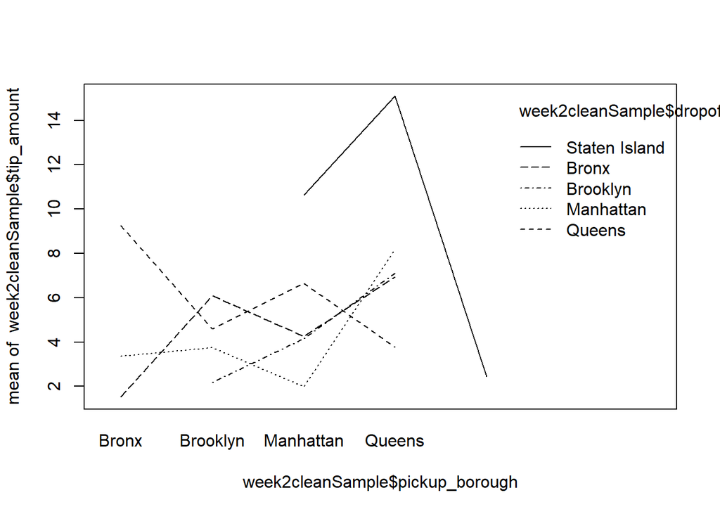

```r
# Explore some interactions between variables
week2cleanSample <- week2clean %>% sample_n(1e5)
interaction.plot(week2cleanSample$pickup_borough, week2cleanSample$dropoff_borough, week2cleanSample$tip_amount)
```

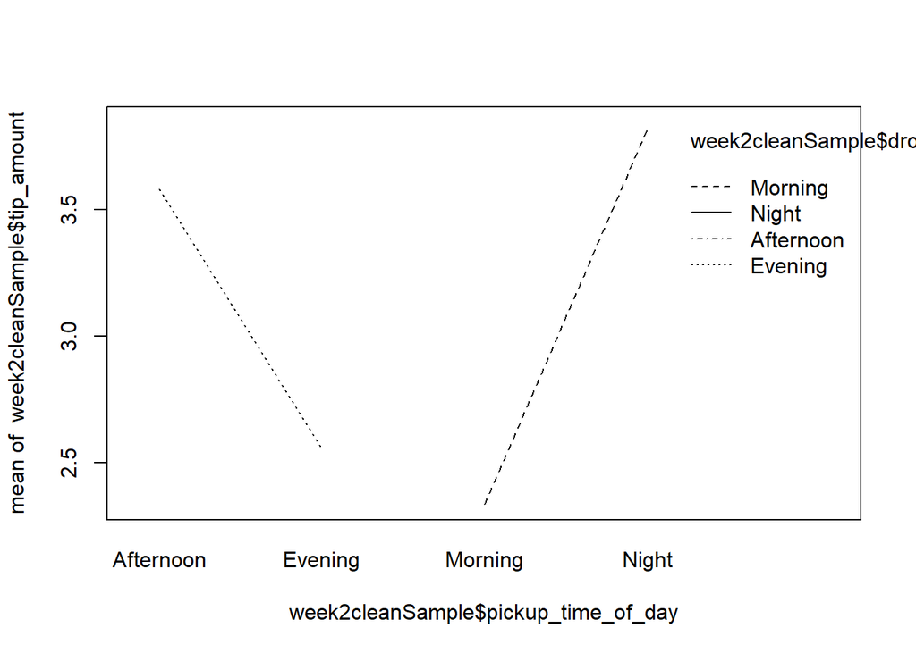

```r
interaction.plot(week2cleanSample$pickup_time_of_day, week2cleanSample$dropoff_time_of_day, week2cleanSample$tip_amount)
```

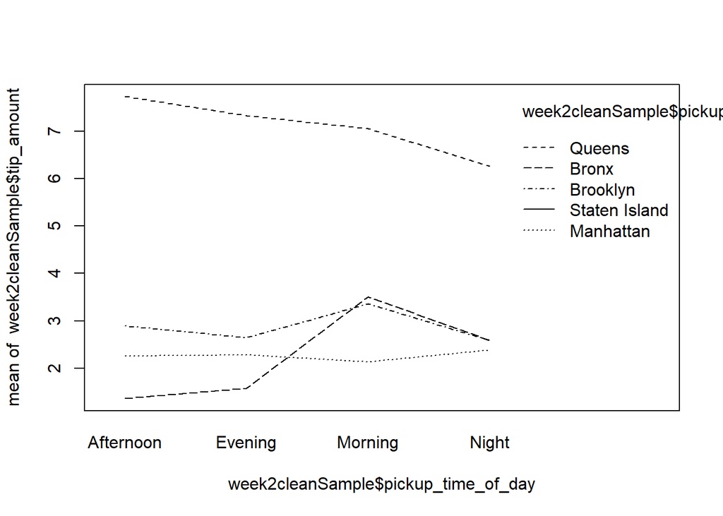

```r
interaction.plot(week2cleanSample$pickup_time_of_day, week2cleanSample$pickup_borough, week2cleanSample$tip_amount)
```

The pickup and dropoff locations/time does have interaction. The pickup and dropoff locations/time does affect the amount of tip as expected

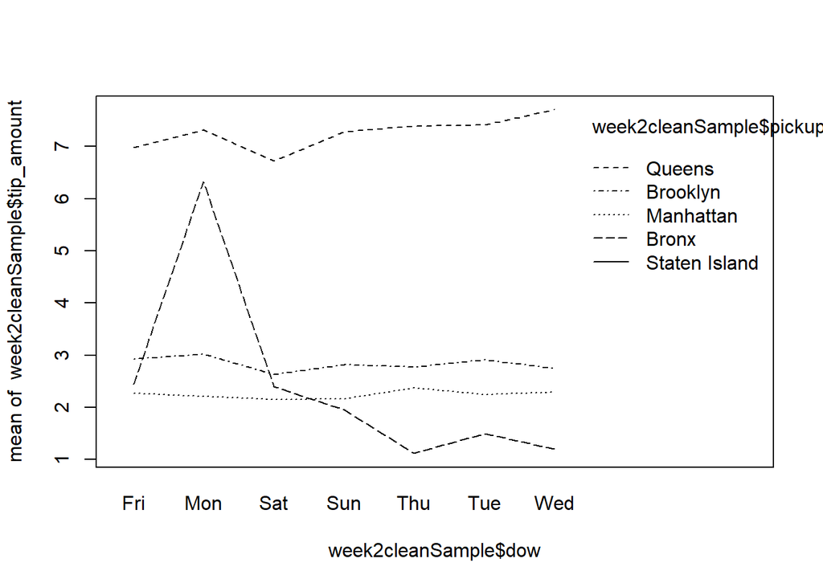

```r
interaction.plot(week2cleanSample$dow, week2cleanSample$pickup_borough, week2cleanSample$tip_amount)
```